[figure not shown]

# Master in Data Science and Big Data Analytics

### "notMNIST Classification"

#### Adriano Fonzino, Maiorino Giordano

L'obiettivo di questo progetto è implementare una **Rete Neurale Convoluzionale** da usare per leggere e classificare circa 20000 immagini delle prime 10 lettere alfabetiche. Infatti le Reti Neurali Convoluzionali (*Convolutional Neural Network*), indicate anche con la sigla **CNN**, sono un particolare tipo di Rete Neurale principalmente usate per il riconoscimento di immagini.

Perchè si è scelto una Rete Neurale Convoluzionale? La CNN è un tipo di rete neurale artificiale feed-forward in cui il pattern di connettività tra i neuroni è ispirato dall'organizzazione della corteccia visiva animale, i cui neuroni individuali sono disposti in maniera tale da rispondere alle regioni di sovrapposizione che tassellano il campo visivo. Le reti convoluzionali sono ispirate da processi biologici e sono variazioni di percettroni multistrato progettate per usare al minimo la pre-elaborazione. Hanno diverse applicazioni nel riconoscimento di immagini e video, nei sistemi di raccomandazione, nell'elaborazione del linguaggio naturale e, recentemente, in bioinformatica.

In questa rete neurale vengono applicati filtri in modo da riconoscere particolari correlazioni o pattern all'interno dell'immagine stessa, in modo da generare caratteristiche ottimali da fornire come input alla rete neurale (normalmente completamente connessa). Da un punto di vista matematico, l'operazione di convoluzione consiste nel "moltiplicare" tra loro due funzioni opportunamente spostate e calcolare quella risultante (supponiamo che una rappresenti la nostra immagine e l'altra il filtro applicato). Dal punto di vista dell'analisi matematica e teoria dei segnali, la convoluzione tra due funzioni f (t) e g (t) è definita come segue:

[figure not shown]

Grazie alle operazioni di convoluzione è possibile applicare filtri specifici per estrarre un insieme di informazioni: ad esempio per quanto riguarda il riconoscimento delle immagini, i bordi di sinistra potrebbero essere estratti con il primo filtro, quelli di destra con il secondo, quello superiore bordi con il terzo, ecc . Al fine di ottenere il livello di precisione ottimale.

Vista la complessità computazionale per addestrare la rete si consigla di importare il presente Jupyter Notebook su google Colab ed impostare una runtime con accelerazione hardware di tipo GPU messa a disposizione da Google, in modo totalmente gratuito.

Sono state utilizzate due diverse librerie per l'implementazione della rete neurale oggetto del presente studio. In particolare, il codice è suddiviso in due parti principali:

1. Utilizzo della libreria di più basso livello **Pytorch**, tramite la quale è stata implementata, addestrata e valutata una CNN con un numero basso di livelli filtro negli strati convolutivi.
2. Utilizzo della libreria di più alto livello **Keras** basata sul backend di **Tensorflow**, tramite la quale è stata implementata, addestrata e valutata una seconda CNN, con struttura analoga alla prima del punto 1, ma con un numero di filtri maggiori negli strati convolutivi per valutare le variazioni di performaces dovute a questi iperparametri.

Il dataset utilizzato è il dataset **notMNIST**, creato da Yaroslav Butalov. Esso è costituito da fonts disponibili pubblicamente dai quali sono stati estratti glyphs simili a quel del famoso dataset MNIST. Esso è costituito da 18726 immagini divise in 10 classi, ognuna rappresentante una lettera dell'alfabeto, dalla A alla J. Le immagini sono dei semplici files .PNG, di dimensione 28x28 pixels. Compito della rete CNN sarà appunto quello di classificare, il più correttamente possibile, le immagini nella classe di appartenenza. Si tratta quindi di un tipico task di classificazione multiclasse, e il traning del modello verrà effettuato tramite un approccio di apprendimento di tipo supervisionato.

## Setup iniziale dell'ambiente di lavoro.

Con il seguente codice verranno effettuati alcuni step preliminari per importare i moduli principali e determinare alcune impostazioni dell'ambiente.

```python
# importazione dei moduli principali.
import datetime
import numpy as np
import pandas as pd
import matplotlib as mpl
import matplotlib.pyplot as plt
from matplotlib import image
import seaborn as sns
from IPython.display import clear_output
import os
import sys
import shutil
import zipfile
from sklearn.preprocessing import LabelEncoder
from sklearn.utils import shuffle
from sklearn.metrics import accuracy_score, precision_score, recall_score, confusion_matrix, classification_report
from sklearn.model_selection import StratifiedKFold
import torch
import torch.nn as nn
import torch.nn.functional as F
# ottimizzatore
import torch.optim as optim
```

```python
# per plottare figure graficamente migliori.
%matplotlib inline
mpl.rc('axes', labelsize=14)
mpl.rc('xtick', labelsize=12)
mpl.rc('ytick', labelsize=12)

PROJECT_ROOT_DIR = os.curdir

# funzione per produrre confusion matrix complete ed esplicative.
def make_confusion_matrix(cf,
                          group_names=None,
                          categories='auto',
                          count=True,
                          percent=True,
                          cbar=True,
                          xyticks=True,
                          xyplotlabels=True,
                          sum_stats=True,
                          figsize=None,
                          cmap='Blues',
                          title=None):
    '''
    ###############################################################################################
    CITATION: taken from: https://github.com/DTrimarchi10/confusion_matrix/blob/master/cf_matrix.py
    ###############################################################################################

    This function will make a pretty plot of an sklearn Confusion Matrix cm using a Seaborn heatmap visualization.
    Arguments
    ---------
    cf:            confusion matrix to be passed in
    group_names:   List of strings that represent the labels row by row to be shown in each square.
    categories:    List of strings containing the categories to be displayed on the x,y axis. Default is 'auto'
    count:         If True, show the raw number in the confusion matrix. Default is True.
    normalize:     If True, show the proportions for each category. Default is True.
    cbar:          If True, show the color bar. The cbar values are based off the values in the confusion matrix.
                   Default is True.
    xyticks:       If True, show x and y ticks. Default is True.
    xyplotlabels:  If True, show 'True Label' and 'Predicted Label' on the figure. Default is True.
    sum_stats:     If True, display summary statistics below the figure. Default is True.
    figsize:       Tuple representing the figure size. Default will be the matplotlib rcParams value.
    cmap:          Colormap of the values displayed from matplotlib.pyplot.cm. Default is 'Blues'
                   See http://matplotlib.org/examples/color/colormaps_reference.html

    title:         Title for the heatmap. Default is None.
    '''


    # CODE TO GENERATE TEXT INSIDE EACH SQUARE
    blanks = ['' for i in range(cf.size)]

    if group_names and len(group_names)==cf.size:
        group_labels = ["{}\n".format(value) for value in group_names]
    else:
        group_labels = blanks

    if count:
        group_counts = ["{0:0.0f}\n".format(value) for value in cf.flatten()]
    else:
        group_counts = blanks

    if percent:
        group_percentages = ["{0:.2%}".format(value) for value in cf.flatten()/np.sum(cf)]
    else:
        group_percentages = blanks

    box_labels = [f"{v1}{v2}{v3}".strip() for v1, v2, v3 in zip(group_labels,group_counts,group_percentages)]
    box_labels = np.asarray(box_labels).reshape(cf.shape[0],cf.shape[1])


    # CODE TO GENERATE SUMMARY STATISTICS & TEXT FOR SUMMARY STATS
    if sum_stats:
        #Accuracy is sum of diagonal divided by total observations
        accuracy  = np.trace(cf) / float(np.sum(cf))

        #if it is a binary confusion matrix, show some more stats
        if len(cf)==2:
            #Metrics for Binary Confusion Matrices
            precision = cf[1,1] / sum(cf[:,1])
            recall    = cf[1,1] / sum(cf[1,:])
            f1_score  = 2*precision*recall / (precision + recall)
            stats_text = "\n\nAccuracy={:0.3f}\nPrecision={:0.3f}\nRecall={:0.3f}\nF1 Score={:0.3f}".format(
                accuracy,precision,recall,f1_score)
        else:
            stats_text = "\n\nAccuracy={:0.3f}".format(accuracy)
    else:
        stats_text = ""


    # SET FIGURE PARAMETERS ACCORDING TO OTHER ARGUMENTS
    if figsize==None:
        #Get default figure size if not set
        figsize = plt.rcParams.get('figure.figsize')

    if xyticks==False:
        #Do not show categories if xyticks is False
        categories=False


    # MAKE THE HEATMAP VISUALIZATION
    plt.figure(figsize=figsize)
    sns.heatmap(cf,annot=box_labels,fmt="",cmap=cmap,cbar=cbar,xticklabels=categories,yticklabels=categories)

    if xyplotlabels:
        plt.ylabel('True label')
        plt.xlabel('Predicted label' + stats_text)
    else:
        plt.xlabel(stats_text)

    if title:
        plt.title(title)
```

Messa a punto del runtime e definizione della GPU da utilizzare come device principale per compiere le operazioni di addestramento della rete in maniera più performante.

```python
if torch.cuda.is_available():
    device = torch.device("cuda:0")  # you can continue going on here, like cuda:1 cuda:2....etc.
    print("Running on the GPU")
else:
    device = torch.device("cpu")
    print("Running on the CPU")
```

```
Running on the GPU
```

```python
# verifica dell'indice del GPU corrente impostata come device.
torch.cuda.current_device()
```

```
0
```

```python
# verifica del modello di GPU corrente utilizzata.
torch.cuda.get_device_name(0)
```

```
'Tesla T4'
```

## Importazione e Visualizzazione dei dati.

```python
os.listdir()
```

```
['.config', 'notMNIST_small.zip', 'sample_data']
```

```python
if os.path.exists("results"):
  shutil.rmtree('results')
  os.makedirs("results")
else:
  os.makedirs("results")

os.listdir()
```

```
['.config', 'results', 'notMNIST_small.zip', 'sample_data']
```

**Nota Bene**: il file zip contentente il dataset compresso deve essere importato manualmente nella cartella del runtime se questo è eseguito su Colab. In alternativa specificare il percorso dove viene inserito il dataset all'interno della variabile *zip_file_path*.

```python
# codice per decomprimere la cartella zippata contenente il dataset.
zip_file_path = os.path.join(PROJECT_ROOT_DIR, 'notMNIST_small.zip')
zip_file_path
```

```
'./notMNIST_small.zip'
```

```python
with zipfile.ZipFile(zip_file_path, 'r') as zip_ref:
    zip_ref.extractall(PROJECT_ROOT_DIR)
```

```python
# Verifica dell'avvenuta decompressione dei file nella nuova cartella.
os.listdir()
```

```
['.config', 'results', 'notMNIST_small.zip', 'notMNIST_small', 'sample_data']
```

```python
# Analisi Esplorativa speditiva per appurare il numero di immagini per ogni classe.

DATA_FOLDER = os.path.join(PROJECT_ROOT_DIR, "notMNIST_small")

data = {}
total_samples = []
for char in os.listdir('notMNIST_small'):
    print("Images for", char, "character are:" , len(os.listdir(os.path.join(DATA_FOLDER, char))))
    total_samples.append(len(os.listdir(os.path.join(DATA_FOLDER, char))))
    data[char] = os.listdir(os.path.join(DATA_FOLDER, char))
print("")
print("Total characters are", len(total_samples))
print("Total Images are:", sum(total_samples))
```

```
Images for D character are: 1873
Images for B character are: 1873
Images for I character are: 1872
Images for E character are: 1873
Images for A character are: 1873
Images for J character are: 1872
Images for C character are: 1873
Images for G character are: 1872
Images for F character are: 1873
Images for H character are: 1872

Total characters are 10
Total Images are: 18726
```

```python
chars = list(data.keys())
chars.sort()
chars
```

```
['A', 'B', 'C', 'D', 'E', 'F', 'G', 'H', 'I', 'J']
```

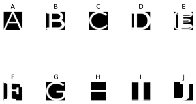

```python
# Visualizzazione immagini esempio per ogni classe del set di dati.
f, axs = plt.subplots(2, 5)
plt.tight_layout()
k = 0
for i in range(2):
    for j in range(5):
        img = image.imread(os.path.join(DATA_FOLDER, chars[k], data[chars[k]][np.random.randint(10)]))
        axs[i][j].imshow(img, cmap="gray", interpolation="none")
        axs[i][j].set_title(chars[k])
        axs[i][j].axis("off")
        k += 1
plt.show()
```

```python
# Consolidazione dei dati all'interno di due liste:
# 1) per i gli array 28x28 delle immagini.
# 2) per i labels di appartenenza alla classe.

counter = 0
img_list = []
labels = []
for char in chars:
  print("===============================================================================================================")
  print(char)
  for img in data[char]:
    try:
      img_ = image.imread(os.path.join(DATA_FOLDER, char, img))
      img_list.append(img_)
      labels.append(char)
      counter +=1
    except:
      print("It hasn't been possible to read ", img)
      continue
print(counter)
```

```
===============================================================================================================
A
It hasn't been possible to read  RGVtb2NyYXRpY2FCb2xkT2xkc3R5bGUgQm9sZC50dGY=.png
===============================================================================================================
B
===============================================================================================================
C
===============================================================================================================
D
===============================================================================================================
E
===============================================================================================================
F
It hasn't been possible to read  Q3Jvc3NvdmVyIEJvbGRPYmxpcXVlLnR0Zg==.png
===============================================================================================================
G
===============================================================================================================
H
===============================================================================================================
I
===============================================================================================================
J
18724
```

```python
img_array = np.array(img_list)
img_array.shape
```

```
(18724, 28, 28)
```

```python
len(labels)
```

```
18724
```

```python
# Conversione della lista degli array 28x28 in un numpy array e
# successivo reshape alle dimensioni corrette per effettuare il feed della rete.
X = img_array.reshape(18724, 1, 28,28)
X_keras = img_array.copy() #copia che verrà utilizzato successivamente nella sezione Keras.
X.shape
```

```
(18724, 1, 28, 28)
```

```python
# Conversione della lista di labels nell'array della variabile target a 10 livelli.
# (dalla lettera A alla lettera J)
y = np.array(labels)
y_keras = y.copy() #copia che verrà utilizzato successivamente nella sezione Keras.
y.shape
```

```
(18724,)
```

```python
# Encoding della variabile categorica target a 10 livelli.
# (dalla lettera A = 0 alla lettera J = 9)
l_encoder = LabelEncoder()
l_encoder.fit(y)
l_encoder.classes_
```

```
array(['A', 'B', 'C', 'D', 'E', 'F', 'G', 'H', 'I', 'J'], dtype='<U1')
```

```python
# Valutazione della
y_encoded = l_encoder.transform(y)
np.unique(y_encoded, return_counts=True)
```

```
(array([0, 1, 2, 3, 4, 5, 6, 7, 8, 9]),
 array([1872, 1873, 1873, 1873, 1873, 1872, 1872, 1872, 1872, 1872]))
```

## Risoluzione problema di "Shuffling"

Per implementare la K-Fold Cross-Validation (CV) useremo la classe **KFold** di **Scikit-learn**. Tuttavia, il mescolamento effettuato dalla classe **KFold** non effettua uno shuffling efficacie come quello della classe Train_test_split, quindi è necessario uno step preliminare di shuffling più casuale. Per far ciò useremo la funzione **shuffle** della libreria **Scikit-learn**. Questo è importante al fine di fornire, durante ogni batch e, ancor di più, durante ogni Fold della CV, un campione abbastanza *esplicativo* e *rappresentativo* dell'intero dataset. In caso contrario, le performance del modello ne risentirebbero fortemente, rendendo impossibili la convergenza del modello.

```python
X, y_encoded = shuffle(X, y_encoded)
```

## Parte1: Implementazione della Convolutional Neural Network con Pytorch

Nel processo di convoluzione abbiamo tre elementi di base:

- L'*immagine in ingresso*: una matrice di pixel rappresentativa dell'immagine. In questo esempio: 28x28 per visualizzare un numero, una lettera o un'icona;
- Il *feature detector o Kernel*: una matrice che funge da filtro attraverso l'operazione di convoluzione;
- La *feature map*: la matrice risultante dalla convoluzione tra l'immagine in ingresso e il kernel;

Alla fine di questo processo, la mappa delle caratteristiche è una matrice, che è più piccola di quella relativa all'immagine di input. Abbiamo perso alcune informazioni sull'immagine in questo passaggio, tuttavia utilizzeremo più filtri di convoluzione (diversi rilevatori di caratteristiche o kernel) per ottenere più mappe di caratteristiche: ognuna di queste memorizzerà le caratteristiche distintive della nostra immagine, ad esempio il contorno giusto, i bordi, i colori più scuri ecc.

Quindi alla rappresentativa matrice di input delle immagini vengono applicati diversi filtri utilizzando operazioni di convoluzione: di conseguenza, otteniamo una serie di *feature map*. A loro volta, le mappe delle caratteristiche vengono sottocampionate mediante un'operazione di *pooling*, per ridurre la complessità considerando solo una parte dei dati. È un processo di riduzione dimensionale che ci permette di semplificare la complessità di una CNN. Di solito sono disponibili due tipi di tecniche: max pooling e average pooling. In pratica, le operazioni di calcolo del valore massimo o medio vengono effettuate su un sottoinsieme dei valori della matrice di input. L'obiettivo principale del pooling è ridurre al minimo la complessità, riducendo quindi l'*overfitting*! Questo processo di convoluzione e sottocampionamento attraverso il raggruppamento viene ripetuto, applicando tra l'altro funzioni di attivazione non lineare alle varie *feature map* ovvero la *Rectified Linear Unit* (RELU). Dopo N Convoluzioni, RELU e Pooling, sarà necessario trasformare le nostre *feature map* raggruppate in un vettore unidimensionale, utilizzando il processo chiamato *Flattening* (appiattimento). Di conseguenza, potremo inserire il vettore risultante in una rete neurale completamente connessa (*fully connected*), cioè dove ogni nodo sarà connesso a tutti gli altri: questo è praticamente il livello nascosto della nostra CNN, che si occupa della previsione e classificazione delle immagini. Alla fine del processo raggiungeremo il livello di output, dove tipicamente applicheremo due tipi di funzioni di attivazione per completare la nostra classificazione delle immagini. Useremo la funzione sigmoide in caso di classificazione binaria, o la sua variante multidimensionale chiamata *softmax*, adatta in caso di classificazione relativa a più categorie.

[figure not shown]

Come è possibile osservare dalla figura precedente, possiamo anche dividere la nostra rete CNN in due passaggi: il primo contiene i livelli iniziali in cui prepariamo le caratteristiche utilizzando i processi di convoluzione, pooling e *flattening*. Possiamo anche associare questa serie di livelli al processo di ingegnerizzazione delle caratteristiche (*feature engineering process*): l'obiettivo è infatti quello di estrarre le caratteristiche dell'immagine che forniremo come input alla rete neurale. Il secondo passaggio consiste in una rete neurale tradizionale, in questo caso completamente connessa, per classificare meglio l'immagine in base alle caratteristiche ricevute in input.

Un altro concetto molto importante è quello di *Dropout*. Questa è un'ulteriore tecnica adottata per ridurre l'*overfitting* durante la classificazione che avviene all'interno della rete neurale completamente connessa. Il *dropout* rimuove in modo casuale alcune connessioni tra due nodi della rete neurale quando i dati di addestramento cambiano.

In questa prima parte di codice, verrà implementata una CNN con 2 strati convolutivi con 5 e 10 filtri, rispettivamente. Ogni **strato convolutivo** sarà seguito da uno strato di **attivazione *Relu*** una **Batch Normalization** e da un **Max-Pooling**. Il vettore linearizzato risultante sarà usato per "nutrire" due strati **densi** che termineranno in uno strato con funzione **Softmax** il quale fornirà come output un vettore di dimensione 10. Un elemento per ogni classe che il classificatore dovrà valutare.

```python
# Generazione di una classe di CNN con Pytorch.

class Net(nn.Module):
  def __init__(self):
    super(Net, self).__init__()
    self.conv1 = nn.Conv2d(1, 5, kernel_size=5)
    self.b_n_1 = nn.BatchNorm2d(5)
    self.conv2 = nn.Conv2d(5, 10, kernel_size=5)
    self.b_n_2 = nn.BatchNorm2d(10)
    self.fc1 = nn.Linear(160, 50)
    self.b_n_3 = nn.BatchNorm1d(50)
    self.fc2 = nn.Linear(50, 10)

    self.relu = nn.ReLU()
    self.drop_1 = nn.Dropout(0.25)
    self.drop_2 = nn.Dropout(0.5)
    self.sm = nn.Softmax()

  def forward(self, x):
    x = self.conv1(x)
    x = self.relu(x)
    x = self.b_n_1(x)
    x = F.max_pool2d(x, 2)
    x = self.conv2(x)
    x = self.relu(x)
    x = self.b_n_2(x)
    x = F.max_pool2d(x, 2)
    x = self.drop_1(x)
    x = x.view(-1, 160)
    x = self.fc1(x)
    x = self.relu(x)
    x = self.b_n_3(x)
    x = self.drop_2(x)
    x = self.fc2(x)
    return self.sm(x)
```

## Loss CrossEntropy

```python
# Definizione di una routine di addestramento che
# verrà eseguita ad ogni singola epoch durante il training della rete.

def train_CE(X_train, y_train, epoch, bs_train, net, opt, dir_results, tr_ls, tr_ct):
  net.train()

  for batch_idx in range(int(X_train.shape[0]/batch_size)):
    data = X_train[batch_idx*batch_size:(batch_idx+1)*batch_size]
    target = y_train[batch_idx*batch_size:(batch_idx+1)*batch_size]
    # assegnare i tensori ala gpu
    data = data.to(device)
    target = target.to(device)
    # settaggio dei gradienti a zero.
    opt.zero_grad()
    # computazione dell'output della rete
    output = net(data)
    # calcolo dell'errore tramite la funzione di costo scelta.
    loss = F.cross_entropy(output, target)
    # calcolo dei gradienti
    loss.backward()
    # passo di learning (learning step)
    opt.step()

    # inizio della stampa del report.........................
    if batch_idx % log_interval == 0:
      num_campioni_elaborati = batch_idx * len(data)
      num_campioni_totali = len(X_train)

      tr_ls.append(loss.item())

      totale_campioni_elaborati =  (batch_idx*bs_train) + (epoch-1)*num_campioni_totali

      tr_ct.append( totale_campioni_elaborati )

      print('Train Epoch: {} [{}/{}  ({:.0f}%)]  \tLoss: {:.6f}'.format(
          epoch, num_campioni_elaborati, num_campioni_totali,
          100. * num_campioni_elaborati / num_campioni_totali,
          loss.item()
          )
      )

      # salvataggio del modello e dei parametri.
      torch.save(net.state_dict(), dir_results + 'model.pth')
      torch.save(opt.state_dict(), dir_results + 'optimizer.pth')
    # fine e print del report.........................

  # ultimo step per batch finale.
  if X_train.shape[0] % batch_size != 0:
    data = X_train[(batch_idx+1)*batch_size:]
    target = y_train[(batch_idx+1)*batch_size:]
    # assegnare i tensori ala gpu
    data = data.to(device)
    target = target.to(device)
    # settaggio dei gradienti a zero.
    opt.zero_grad()
    # computazione dell'output della rete
    output = net(data)
    # calcolo dell'errore tramite la funzione di costo scelta
    loss = F.cross_entropy(output, target)
    # calcolo dei gradienti
    loss.backward()
    # passo di learning (learning step)
    opt.step()

    # inizio della stampa del report.........................
    if batch_idx % log_interval == 0:
      num_campioni_elaborati = batch_idx * len(data)
      num_campioni_totali = len(X_train)

      tr_ls.append(loss.item())

      totale_campioni_elaborati =  (batch_idx*bs_train) + (epoch-1)*num_campioni_totali

      tr_ct.append( totale_campioni_elaborati )

      print('Train Epoch: {} [{}/{}  ({:.0f}%)]  \tLoss: {:.6f}'.format(
          epoch, num_campioni_elaborati, num_campioni_totali,
          100. * num_campioni_elaborati / num_campioni_totali,
          loss.item()
          )
      )

      # salvataggio del modello e dei parametri.
      torch.save(net.state_dict(), dir_results + 'model.pth')
      torch.save(opt.state_dict(), dir_results + 'optimizer.pth')
    # fine e print del report.........................

  return tr_ls, tr_ct
```

```python
# funzione per lo step di valutazione sul test set.

def test_CE(tls, net, X_test, y_test):

    net.eval()
    test_loss = 0
    correct = 0

    # to avoid grandient computation
    with torch.no_grad():
      for test_batch_idx in range(int(X_test.shape[0]/test_batch_size)):
        data = X_test[test_batch_idx*test_batch_size: (test_batch_idx+1)*test_batch_size]
        target = y_test[test_batch_idx*test_batch_size: (test_batch_idx+1)*test_batch_size]
        # put datasets on gpu
        data = data.to(device)
        target = target.to(device)
        # calculate output
        output = net(data)
        ##################################
        test_loss += F.cross_entropy(output, target, size_average=False).item()
        ##################################
        pred = output.data.max(1, keepdim=True)[1]
        correct += pred.eq(target.data.view_as(pred)).sum()

    test_loss /= len(X_test)
    tls.append(test_loss)

    print('\nTest set: Avg. loss: {:.4f}, Accuracy: {}/{} ({:.0f}%)\n'.format(
        test_loss, correct, len(X_test),
        100. * correct / len(X_test)))
    return tls
```

```python
# Funzione per il calcolo delle metriche della rete sul test dopo ogni paso della
# 10-Fold Cross Validation.
def get_metrics(y_test, y_predicted, plot_cfm = False):
  accuracy = accuracy_score(y_test, y_predicted)
  precision = precision_score(y_test, y_predicted, average = "weighted")
  recall = recall_score(y_test, y_predicted, average = "weighted")
  conf_matrix = confusion_matrix(y_test, y_predicted)
  report = classification_report(y_test, y_predicted, output_dict=True)

  labels = ["True Neg", "False Pos", "False Neg", "True Pos"]
  categories = l_encoder.classes_
  if plot_cfm:
    make_confusion_matrix(conf_matrix,
                          group_names=labels,
                          categories=categories,
                          title="Confusion Matrix on Test set for the CNN classifier",
                          figsize=(10,10))

  return accuracy, precision, recall, conf_matrix, report
```

## 10-Fold Cross-Validation

```python
# Implementazione della 10-Fold Cross Validation

cv = StratifiedKFold(n_splits=10, shuffle=True, random_state=10)

metrics = {"accuracies":[],
           "precisions":[],
           "recalls":[],
           "confusion_matrices":[],
           "classification_reports":[],
           "train_losses":[],
           "test_losses":[],
           "train_counter":[],
           "test_counter":[]}

fold_counter = 1
for train_index, test_index in cv.split(X, y_encoded):
  # Split dei dati in train e test datasets e conversione degli stessi in Tensori.
  X_train = torch.from_numpy(X[train_index])
  X_test =  torch.from_numpy(X[test_index])
  y_train = torch.from_numpy(y_encoded[train_index])
  y_test =  torch.from_numpy(y_encoded[test_index])

  print("\n ### Training Fold {} of 10...".format(fold_counter))
  print(X_train.shape, type(X_train))
  print(X_test.shape, type(X_test))
  print(y_train.shape, type(y_train))
  print(np.unique(y_train.numpy(), return_counts=True))
  print(y_test.shape, type(y_test))
  print(np.unique(y_test.numpy(), return_counts=True))
  print("")

  # Training........
  batch_size = 128
  test_batch_size = 206

  learning_rate = 0.001
  momentum = 0.5

  network_CE = Net().to(device)
  optimizer_CE = optim.Adam(network_CE.parameters(), lr=learning_rate)

  n_epochs = 10

  train_losses = []
  train_counter = []
  test_losses = []

  test_counter = [i*len(X_train) for i in range(n_epochs +1)]

  test_losses = test_CE(test_losses, network_CE, X_test, y_test)

  log_interval = 25  # passo a cui salvare i dati di log

  for epoch in range(1, n_epochs + 1):

    train_losses, train_counter = train_CE(X_train, y_train, epoch, batch_size, network_CE, optimizer_CE, "./results/", train_losses, train_counter)
    test_losses = test_CE(test_losses, network_CE, X_test, y_test)

  # Valuazione delle Metriche della rete
  # Calcolo delle predizioni sul test set.
  with torch.no_grad():
    output = network_CE(X_test.to(device))

  # salvataggio delle metriche in una tupla.
  current_fold_metrics = get_metrics(y_test, output.data.max(1, keepdim=True)[1].tolist())
  metrics["accuracies"].append(current_fold_metrics[0])
  metrics["precisions"].append(current_fold_metrics[1])
  metrics["recalls"].append(current_fold_metrics[2])
  metrics["confusion_matrices"].append(current_fold_metrics[3])
  metrics["classification_reports"].append(current_fold_metrics[4])
  metrics["train_losses"].append(train_losses)
  metrics["test_losses"].append(test_losses)
  metrics["train_counter"].append(train_counter)
  metrics["test_counter"].append(test_counter)

  print("Fold n° {} of 10 has finished\n=====================================================================================\n".format(fold_counter))
  fold_counter += 1

print("10-Fold Cross-Validation has finished.")
```

```
 ### Training Fold 1 of 10...
torch.Size([16851, 1, 28, 28]) <class 'torch.Tensor'>
torch.Size([1873, 1, 28, 28]) <class 'torch.Tensor'>
torch.Size([16851]) <class 'torch.Tensor'>
(array([0, 1, 2, 3, 4, 5, 6, 7, 8, 9]), array([1685, 1686, 1686, 1686, 1686, 1684, 1684, 1685, 1684, 1685]))
torch.Size([1873]) <class 'torch.Tensor'>
(array([0, 1, 2, 3, 4, 5, 6, 7, 8, 9]), array([187, 187, 187, 187, 187, 188, 188, 187, 188, 187]))
```

```
Test set: Avg. loss: 2.2797, Accuracy: 190/1873 (10%)

Train Epoch: 1 [0/16851  (0%)]  	Loss: 2.306608
Train Epoch: 1 [3200/16851  (19%)]  	Loss: 2.093574
Train Epoch: 1 [6400/16851  (38%)]  	Loss: 1.936718
Train Epoch: 1 [9600/16851  (57%)]  	Loss: 1.885207
Train Epoch: 1 [12800/16851  (76%)]  	Loss: 1.828106
Train Epoch: 1 [16000/16851  (95%)]  	Loss: 1.865119

Test set: Avg. loss: 1.6919, Accuracy: 1511/1873 (81%)

Train Epoch: 2 [0/16851  (0%)]  	Loss: 1.727012
Train Epoch: 2 [3200/16851  (19%)]  	Loss: 1.731041
Train Epoch: 2 [6400/16851  (38%)]  	Loss: 1.641822
Train Epoch: 2 [9600/16851  (57%)]  	Loss: 1.683010
Train Epoch: 2 [12800/16851  (76%)]  	Loss: 1.692793
Train Epoch: 2 [16000/16851  (95%)]  	Loss: 1.724175

Test set: Avg. loss: 1.5828, Accuracy: 1632/1873 (87%)

Train Epoch: 3 [0/16851  (0%)]  	Loss: 1.623284
Train Epoch: 3 [3200/16851  (19%)]  	Loss: 1.646464
Train Epoch: 3 [6400/16851  (38%)]  	Loss: 1.610627
Train Epoch: 3 [9600/16851  (57%)]  	Loss: 1.594220
Train Epoch: 3 [12800/16851  (76%)]  	Loss: 1.646208
Train Epoch: 3 [16000/16851  (95%)]  	Loss: 1.690673

Test set: Avg. loss: 1.5649, Accuracy: 1649/1873 (88%)

Train Epoch: 4 [0/16851  (0%)]  	Loss: 1.578391
Train Epoch: 4 [3200/16851  (19%)]  	Loss: 1.594947
Train Epoch: 4 [6400/16851  (38%)]  	Loss: 1.592557
Train Epoch: 4 [9600/16851  (57%)]  	Loss: 1.578011
Train Epoch: 4 [12800/16851  (76%)]  	Loss: 1.624171
Train Epoch: 4 [16000/16851  (95%)]  	Loss: 1.641303

Test set: Avg. loss: 1.5572, Accuracy: 1659/1873 (89%)

Train Epoch: 5 [0/16851  (0%)]  	Loss: 1.580686
Train Epoch: 5 [3200/16851  (19%)]  	Loss: 1.605913
```

[output cut: 986 more lines]

```
Test set: Avg. loss: 1.5404, Accuracy: 1684/1872 (90%)

Train Epoch: 10 [0/16852  (0%)]  	Loss: 1.540313
Train Epoch: 10 [3200/16852  (19%)]  	Loss: 1.570636
Train Epoch: 10 [6400/16852  (38%)]  	Loss: 1.554823
Train Epoch: 10 [9600/16852  (57%)]  	Loss: 1.527034
Train Epoch: 10 [12800/16852  (76%)]  	Loss: 1.560211
Train Epoch: 10 [16000/16852  (95%)]  	Loss: 1.584981

Test set: Avg. loss: 1.5363, Accuracy: 1689/1872 (90%)

Fold n° 10 of 10 has finished
=====================================================================================

10-Fold Cross-Validation has finished.
```

```python
# Estrazione delle metriche e calcolo medie e deviazioni standard
train_losses_mean = np.round(np.mean(np.array(metrics["train_losses"]), axis=0), 4).flatten()
train_losses_std = np.round(np.std(np.array(metrics["train_losses"]), axis=0), 4).flatten()
test_losses_mean = np.round(np.mean(np.array(metrics["test_losses"]), axis=0), 4).flatten()
test_losses_std = np.round(np.std(np.array(metrics["test_losses"]), axis=0), 4).flatten()
```

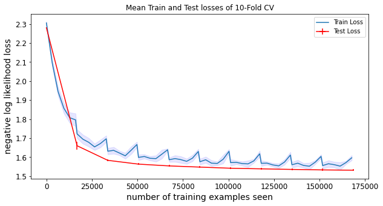

```python
# Visualizzazione della Validation Curve della funzione di costo.
plt.figure(figsize=(10,5))
plt.plot(metrics["train_counter"][0], train_losses_mean, label = 'Train Loss')
plt.fill_between(metrics["train_counter"][0],
                 (train_losses_mean-train_losses_std),
                 (train_losses_mean+train_losses_std),
                 color='b',
                 alpha=.1)
plt.errorbar(x=test_counter, y=test_losses_mean, xerr=test_losses_std, yerr=test_losses_std,
             color="red", label = "Test Loss")

plt.title("Mean Train and Test losses of 10-Fold CV")
plt.xlabel('number of training examples seen')
plt.ylabel('negative log likelihood loss')
plt.legend()
plt.show()
```

```python
# Stampa delle metriche medie della CNN durante la 10-Fold CV.

for metric, key in zip(["Accuracy", "Precision", "Recall"], list(metrics.keys())[0:3]):
  print("Mean {} +/- std: {} +/- {}".format(metric, round(np.mean(metrics[key]), 4), round(np.std(metrics[key]), 4)))
```

```
Mean Accuracy +/- std: 0.9168 +/- 0.0055
Mean Precision +/- std: 0.9177 +/- 0.0052
Mean Recall +/- std: 0.9168 +/- 0.0055
```

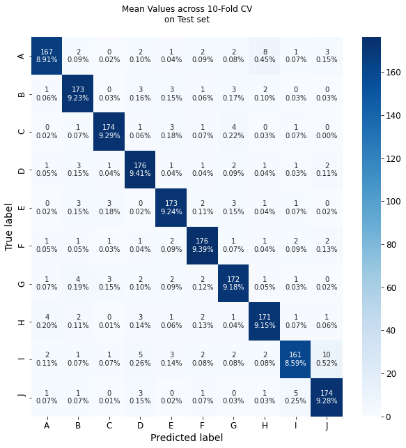

```python
# Visualizzazione della Confusion Matrix.
# Ogni cella mostra il valore medio ottenuto nelle 10 iterazione durante la CV.

make_confusion_matrix(np.mean(np.array(metrics["confusion_matrices"]), axis=0),
                      categories = chars,
                      figsize=(10,10),
                      sum_stats=False,
                      title="Mean Values across 10-Fold CV\non Test set\n")
```

```python
print(metrics["classification_reports"][1])
```

[output not shown]

```python
# Visualizzazione dei Classification Reports di ogni step della CV.

print("============================================================")
print("================== Classification Reports ==================")
print("============================================================")
for fold in range(0,10):
  print("Fold n°", fold+1)
  print(metrics["classification_reports"][fold])
  print("============================================================")
```

[output not shown]

## Parte 2: Implementazione del Convolutional Neural Network più profonda con **Keras**

In questa seconda parte, usando la libreria **Keras**, verrà implementata una CNN con un maggior numero di filtri (64 per ogni strato) nei 2 strati convolutivi iniziali. La rete sarà addestrata e valutata sempre tramite 10-Fold Cross Validation. In questo caso lo step preliminare di pre-shuffling non si è reso necessario poichè il backend Keras basato su Tensorflow, provvede in autonomia al corretto shuffling dei dati, ottenendo dei Fold più equilibrati e rappresentativi delle varie classi.

**1. Import e modellazione dei dati:**

```python
from PIL import Image
from random import randrange

from sklearn.model_selection import KFold
from sklearn.preprocessing import OneHotEncoder
from keras.models import Sequential, load_model
from keras.layers import Activation, BatchNormalization, Dense, Dropout, Flatten ,Conv2D, MaxPooling2D
from keras.regularizers import l1_l2
from keras.callbacks import ModelCheckpoint
from keras.backend import clear_session
```

Con il codice seguente, sfruttando l'import delle immagini da classificare realizzato in precedenza, si procede a classificare i valori contenuti in y utilizzando OneHotEncoder di sklearn per darli poi in input alla funzione di attivazione "softmax" della CNN

```python
img_size = 28 # width of image
X = X_keras.reshape(X.shape[0], img_size, img_size, 1)

ohe = OneHotEncoder()
y = y_keras.reshape(len(labels), 1)
ohe.fit(y)
y = ohe.transform(y).toarray()
```

**2. Definizione della CNN**

Di seguito entriamo nel vivo della sperimentazione, realizzando una fase di apprendimento e la successiva previsione con una vera CNN. Come libreria di *deep learning* si utilizzerà **Tensorflow** come piattaforma di *backend* e **Keras** come *frontend*: quest'ultimo fornisce **API** (*Application Programming Interface*) di alto livello, che ci permette di progettare il modello CNN in modo davvero intuitivo.

Implementiamo una rete neurale convoluzionale consiste in un livello di convoluzione con 2 matrici da 64 nodi, ciscuna seguita dalla funzione di attivazione ReLU, uno strato di riduzione dimensionale basato su pooling e dropout. Successivamente, tramite il processo di flatting il risultato è "appiattito" per ottenere il vettore unidimensionale e viene fornito come input ad un livello di rete neurale *fully connected* composta da 128 nodi applicando ReLU e ulteriore dropout. Il livello di output è costituito da una rete neurale a 10 nodi, lunghezza del nostro array di output con la probabilità che l'immagine contenga i numeri da 0 a 9 (in questo esempio rappresentano la codifica delle lettere dalla A alla J) e dalla funzione di attivazione non lineare *softmax*.

```python
# PARAMETERS
batch_size = 128
nb_classes = 10 # dimensionality of the output space in the Dense function
nb_epoch = 10
reg = l1_l2(l1=0, l2=0.02)

#STRUCTURE
# input image dimensions
img_rows, img_cols = 28, 28
# number of convolutional filters to use
nb_filters = 64
# size of pooling area for max pooling
pool_size = [2, 2]
# convolution kernel size
kernel_size = [3, 3]

input_shape = [img_rows, img_cols, 1]
```

```python
# MODEL LAYERS
classifier = Sequential()
#1st convolution and pooling layer”
classifier.add(Conv2D(nb_filters, kernel_size, padding='same', input_shape=input_shape))
classifier.add(Activation('relu'))
classifier.add(BatchNormalization())
classifier.add(Conv2D(nb_filters, kernel_size, padding='same'))
classifier.add(Activation('relu'))
classifier.add(BatchNormalization())
classifier.add(MaxPooling2D(pool_size=pool_size))
classifier.add(Dropout(0.25))
#Flattening
classifier.add(Flatten())
#1st fully connected Neural Network hidden-layer”
classifier.add(Dense(128, kernel_regularizer=reg))
classifier.add(Activation('relu'))
classifier.add(BatchNormalization())
classifier.add(Dropout(0.5))
#Output layer
classifier.add(Dense(nb_classes, kernel_regularizer=reg))
classifier.add(Activation('softmax'))

classifier.compile(optimizer='adam', loss='categorical_crossentropy', metrics=['accuracy'])
#Adam optimization is a stochastic gradient descent method that is based on adaptive estimation of first-order and second-order moments.
#categorical_crossentropy: for classification problem
classifier.summary()
```

```
Model: "sequential"
_________________________________________________________________
Layer (type)                 Output Shape              Param #
=================================================================
conv2d (Conv2D)              (None, 28, 28, 64)        640
_________________________________________________________________
activation (Activation)      (None, 28, 28, 64)        0
_________________________________________________________________
batch_normalization (BatchNo (None, 28, 28, 64)        256
_________________________________________________________________
conv2d_1 (Conv2D)            (None, 28, 28, 64)        36928
_________________________________________________________________
activation_1 (Activation)    (None, 28, 28, 64)        0
_________________________________________________________________
batch_normalization_1 (Batch (None, 28, 28, 64)        256
_________________________________________________________________
max_pooling2d (MaxPooling2D) (None, 14, 14, 64)        0
_________________________________________________________________
dropout (Dropout)            (None, 14, 14, 64)        0
_________________________________________________________________
flatten (Flatten)            (None, 12544)             0
_________________________________________________________________
dense (Dense)                (None, 128)               1605760
_________________________________________________________________
activation_2 (Activation)    (None, 128)               0
_________________________________________________________________
batch_normalization_2 (Batch (None, 128)               512
_________________________________________________________________
dropout_1 (Dropout)          (None, 128)               0
_________________________________________________________________
dense_1 (Dense)              (None, 10)                1290
_________________________________________________________________
activation_3 (Activation)    (None, 10)                0
=================================================================
Total params: 1,645,642
Trainable params: 1,645,130
Non-trainable params: 512
_________________________________________________________________
```

**3. Fit del modello e valutazione tramite Cross validation**

Altri due parametri relativi a concetti non ancora illustrati, tipici dei modelli CNN sono *epochs* e *batch_size*. Per adattare il modello, l'intero set di dati di addestramento viene fornito come input molte volte, con l'obiettivo di migliorare la precisione. Ogni volta che ripetiamo questa operazione, stiamo correndo un'epoca. La dimensione del *batch* definisce invece il numero di dati di addestramento elaborati prima dell'aggiornamento dei parametri del modello. Ad esempio, nel nostro caso di CNN i pesi utilizzati per sommare i dati di input relativi a ciascun nodo della rete neurale. Per questa rete neurale convoluzionale abbiamo stabilito che 128 immagini devono essere elaborate ogni volta, prima che l'ottimizzatore della CNN possa modificare qualsiasi parametro.

```python
#indicare il percorso dove salvare i modelli
model_path = '/content/saved_models_keras/'
```

```python
kf = KFold(n_splits = 10, shuffle=True)
#Provides train/test indices to split data in train/test sets.
#Split dataset into k consecutive folds (without shuffling by default).
#Each fold is then used once as a validation while the k - 1 remaining folds form the training set

#shuffle=True è necessario per evitare che le immagini vengano caricate in maniera sqeuenziale
#ed evitare che il modello si addestri in questo caso ad esempio su tutte A
#e faccia poi la validation sulla lettera J ottenendo un'accuracy quindi pari a zero

validation_accuracy = []
validation_loss = []
classifier_history = []
model_number = 1

weights_save = classifier.get_weights()
#memorizzo lo stato inizale dei pesi per far sì che il fit su ogni fold avvenga
#in maniera del tutto indipendente dal precedente

for train_index, test_index in kf.split(X,y):

  print('\n\nfit the CNN number: {actual_number} of {total_number}\n\n'.format(
      actual_number = model_number, total_number = kf.get_n_splits()))

  #1. divisione train and test set
  X_train = X[train_index]
  X_test = X[test_index]
  y_train = y[train_index]
  y_test = y[test_index]

  #2. definiamo una CALLBACKS per il salvataggio dei modelli
  single_model_path = model_path + 'model_' + str(model_number) + '.h5'
  checkpoint = ModelCheckpoint(single_model_path,
                               monitor='val_accuracy', verbose=1,
                               save_best_only=True, mode='max')
  #se la directory non è già esistente viene automaticamente creata

  #3. fit del modello
  history = classifier.fit(X_train, y_train,
                           batch_size=batch_size, epochs=nb_epoch,
                           verbose=1,
                           shuffle=True, #to shuffle the training data before each epoch
                           validation_data=(X_test, y_test),
                           callbacks=checkpoint)

  #4. salvataggio dei migliori paramteri ottenuti sul testset per ciascun modello
  classifier_history.append(history)
  validation_accuracy.append(max(history.history['val_accuracy']))
  validation_loss.append(min(history.history['val_loss']))

  #5. Ripristino i pesi del modello allo stato iniziale
  classifier.set_weights(weights_save)

  model_number += 1
```

```
fit the CNN number: 1 of 10



Epoch 00001: val_accuracy improved from -inf to 0.09717, saving model to /content/saved_models_keras/model_1.h5

Epoch 00002: val_accuracy did not improve from 0.09717

Epoch 00003: val_accuracy did not improve from 0.09717

Epoch 00004: val_accuracy improved from 0.09717 to 0.28457, saving model to /content/saved_models_keras/model_1.h5

Epoch 00005: val_accuracy improved from 0.28457 to 0.88681, saving model to /content/saved_models_keras/model_1.h5

Epoch 00006: val_accuracy improved from 0.88681 to 0.92525, saving model to /content/saved_models_keras/model_1.h5

Epoch 00007: val_accuracy improved from 0.92525 to 0.93380, saving model to /content/saved_models_keras/model_1.h5

Epoch 00008: val_accuracy improved from 0.93380 to 0.93593, saving model to /content/saved_models_keras/model_1.h5

Epoch 00009: val_accuracy did not improve from 0.93593

Epoch 00010: val_accuracy did not improve from 0.93593


fit the CNN number: 2 of 10



Epoch 00001: val_accuracy improved from -inf to 0.10945, saving model to /content/saved_models_keras/model_2.h5

Epoch 00002: val_accuracy did not improve from 0.10945

Epoch 00003: val_accuracy did not improve from 0.10945

Epoch 00004: val_accuracy improved from 0.10945 to 0.47891, saving model to /content/saved_models_keras/model_2.h5

Epoch 00005: val_accuracy improved from 0.47891 to 0.88041, saving model to /content/saved_models_keras/model_2.h5

Epoch 00006: val_accuracy improved from 0.88041 to 0.93593, saving model to /content/saved_models_keras/model_2.h5
```

[output cut: 193 more lines]

```
Epoch 00003: val_accuracy improved from 0.09722 to 0.12286, saving model to /content/saved_models_keras/model_10.h5

Epoch 00004: val_accuracy improved from 0.12286 to 0.55716, saving model to /content/saved_models_keras/model_10.h5

Epoch 00005: val_accuracy improved from 0.55716 to 0.87660, saving model to /content/saved_models_keras/model_10.h5

Epoch 00006: val_accuracy improved from 0.87660 to 0.92254, saving model to /content/saved_models_keras/model_10.h5

Epoch 00007: val_accuracy improved from 0.92254 to 0.92628, saving model to /content/saved_models_keras/model_10.h5

Epoch 00008: val_accuracy did not improve from 0.92628

Epoch 00009: val_accuracy improved from 0.92628 to 0.93590, saving model to /content/saved_models_keras/model_10.h5

Epoch 00010: val_accuracy did not improve from 0.93590
```

**4. Valutazione delle CNN sul Testset**

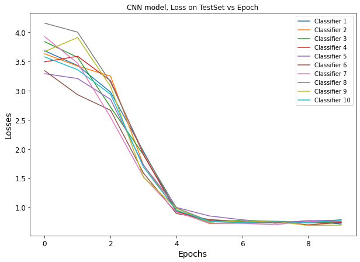

```python
# Plotting Loss vs Epochs
plt.figure(figsize =(10,7))
for i in range(len(classifier_history)):
  plt.plot(classifier_history[i].history["val_loss"], label='Classifier {}'.format(i+1))
plt.xlabel("Epochs")
plt.ylabel("Losses")
plt.title("CNN model, Loss on TestSet vs Epoch")
plt.legend()
plt.show()
```

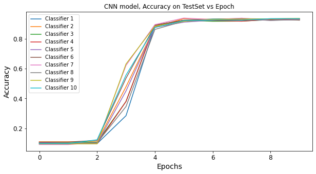

```python
# Plotting Accuracy vs Epochs
plt.figure(figsize =(10,5))
for i in range(len(classifier_history)):
  plt.plot(classifier_history[i].history["val_accuracy"], label='Classifier {}'.format(i+1))
plt.xlabel("Epochs")
plt.ylabel("Accuracy")
plt.title("CNN model, Accuracy on TestSet vs Epoch")
plt.legend()
plt.show()
```

Dai grafici è possibile dedure che a partire dalla epoca numero 4, per ogni Rete Neurale Convoluzionale addestrata, si inzia ad ottenere un ottimo valore di Loss e di Accuracy sul TestSet.

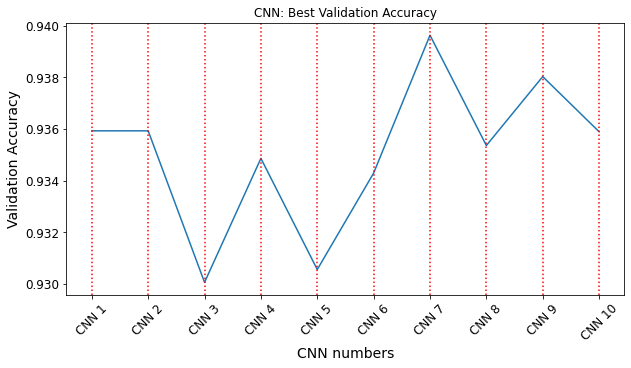

```python
# Plotting Best Validation Accuracy by CNN
plt.figure(figsize =(10,5))
plt.plot(validation_accuracy)
for i in range(len(validation_accuracy)):
  plt.axvline(i, linestyle='dotted', color='red')
plt.xticks(ticks=range(len(validation_accuracy)), rotation=45,
           labels=['CNN {}'.format(i+1) for i in range(len(validation_accuracy))])
plt.xlabel("CNN numbers")
plt.ylabel("Validation Accuracy")
plt.title("CNN: Best Validation Accuracy")
plt.show()
```

```python
max_accuracy_value = max(validation_accuracy)
max_accuracy_model_number = validation_accuracy.index(max(validation_accuracy)) + 1
print('La CNN con la maigliore accuracy sul TestSet in fase di Training è la numero {0} con un valore di {1}'.format(
    max_accuracy_model_number, max_accuracy_value))
```

```
La CNN con la maigliore accuracy sul TestSet in fase di Training è la numero 7 con un valore di 0.939636766910553
```

**5. Carichiamo in memoria la CNN desiderata**

```python
my_cnn_number = max_accuracy_model_number
#in alternativa il numero del modello di CNN desiderato. Esempio:
#my_cnn_number = 1
classifier_path = model_path + 'model_' + str(my_cnn_number) + '.h5'
print(classifier_path)
```

```
/content/saved_models_keras/model_7.h5
```

```python
#Per caricare in memoria solo i pesi del modello.
#Da utilizzare se il modello è già stato definito!
classifier.load_weights(classifier_path)
```

```python
#Per caricare in memoria tutto il modello senza doverlo ridefinire
#classifier = load_model(classifier_path)
```

**6. Valutazione e predizione sul TestSet della CNN selezionata**

```python
offset = 65 #necessario per trasformare la predizione da numero a lettera: 0 -> A -> 65 in ASCII
```

```python
preds_df = pd.DataFrame(classifier.predict(X_test))
predicted_letter = preds_df.idxmax(axis=1) #convert back to categorical variabless
predicted_letters = predicted_letter.apply(lambda x: chr(offset + x))
real_letters = ohe.inverse_transform(y_test)
```

```python
print(classification_report(real_letters, predicted_letters))
```

```
              precision    recall  f1-score   support

           A       0.96      0.96      0.96       185
           B       0.98      0.91      0.95       190
           C       0.95      0.92      0.94       199
           D       0.97      0.97      0.97       185
           E       0.93      0.96      0.94       203
           F       0.98      0.96      0.97       179
           G       0.91      0.97      0.94       198
           H       0.94      0.96      0.95       170
           I       0.92      0.93      0.93       182
           J       0.96      0.96      0.96       181

    accuracy                           0.95      1872
   macro avg       0.95      0.95      0.95      1872
weighted avg       0.95      0.95      0.95      1872
```

Il rapporto di classificazione riguarda le metriche chiave in un problema di classificazione ovvero, quante previsioni sono vere e quante sono false. Più specificamente, Veri positivi, Falsi positivi, Veri negativi e Falsi negativi vengono utilizzati per prevedere le seguenti metriche:

- il *recall* è la capacità di un classificatore di trovare tutte le istanze positive. Per ogni classe è definito come il rapporto tra i veri positivi e la somma dei veri positivi e dei falsi negativi;
- la *precision* è la capacità di un classificatore di non etichettare un'istanza positiva che è effettivamente negativa. Per ogni classe è definito come il rapporto tra i veri positivi e la somma dei veri e falsi positivi;
- l' *f1-score* è una media armonica ponderata di precisione e richiamo tale che il punteggio migliore è 1.0 e il peggiore è 0.0. In generale, i punteggi f1 sono inferiori alle misure di accuratezza poiché incorporano precisione e richiamo nel loro calcolo. Come regola generale, per confrontare i modelli di classificazione dovrebbe essere utilizzata la media ponderata di f1, non l'accuratezza globale;
- il *support* è il numero di occorrenze della classe data nel set di dati.

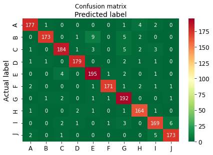

```python
#Stampa la confusion matrix
cm = confusion_matrix(real_letters, predicted_letters)
label_names=sorted(list(predicted_letters.unique()))
fig, ax = plt.subplots()
# create heatmap
sns.heatmap(pd.DataFrame(cm, index=label_names, columns=label_names), annot=True, cmap="RdYlGn_r", fmt='g')
ax.xaxis.set_label_position("top")
plt.tight_layout()
plt.title('Confusion matrix', y=1.1)
plt.ylabel('Actual label')
plt.xlabel('Predicted label')
plt.show()
```

Si effettua di seguito un controllo di 9 campioni casuali prelevati da X_test associando a ciscuna immagine prelevata la rispettiva lettera predetta dalla Rete Neurale Convoluzionale.

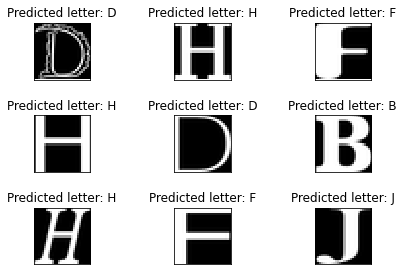

```python
f, axs = plt.subplots(3,3)
plt.tight_layout()

for i in range(3):
    for j in range(3):
        random_img = X_test[randrange(len(X_test))]
        axs[i][j].imshow(random_img.reshape(img_size, img_size), cmap='gray', interpolation='none')
        #reshape necessario per la stampa
        axs[i][j].set_title("Predicted letter: {}".format(
            chr(offset + np.argmax(classifier.predict(random_img.reshape(1, img_size, img_size, 1))))))
        #reshape necessario per darlo in input alla CNN
        axs[i][j].set_xticks([])
        axs[i][j].set_yticks([])

plt.show()
```